# Week 2 Course Project Activity Data

## Part 1: Code for reading in the dataset and/or processing the data

Data file found on https://d396qusza40orc.cloudfront.net/repdata%2Fdata%2Factivity.zip

Data file has been downloaded to working directory and unzipped into csv file.

Read File

```r
setwd("D:/CourseRA/Reproducable Research/Week 2")

ActivityData<-read.csv("activity.csv")
summary(ActivityData)
```

```
##      steps                date          interval
##  Min.   :  0.00   2012-10-01:  288   Min.   :   0.0
##  1st Qu.:  0.00   2012-10-02:  288   1st Qu.: 588.8
##  Median :  0.00   2012-10-03:  288   Median :1177.5
##  Mean   : 37.38   2012-10-04:  288   Mean   :1177.5
##  3rd Qu.: 12.00   2012-10-05:  288   3rd Qu.:1766.2
##  Max.   :806.00   2012-10-06:  288   Max.   :2355.0
##  NA's   :2304     (Other)   :15840
```

Summary of data is shown to look at data format and identify any missing or NA fields.

## Part 2:Histogram of the total number of steps taken each day

Examine steps on a daily basis

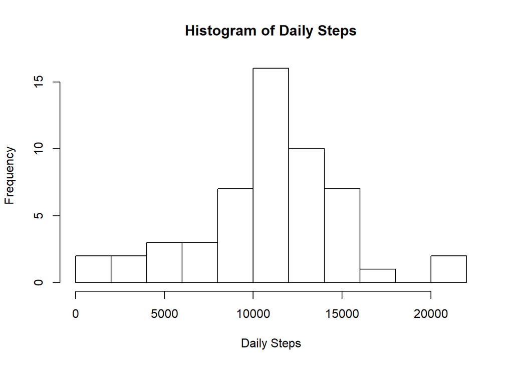

```r
DailyData<-aggregate(ActivityData$steps, list(ActivityData$date),FUN=sum)
names(DailyData)[1]<-"Date"
names(DailyData)[2]<-"DailySteps"
DailyData$Date<-as.Date(DailyData$Date, format="%Y-%m-%d")
hist(DailyData$DailySteps,breaks=10,xlab="Daily Steps",main="Histogram of Daily Steps")
```

## Part 3: Mean and median number of steps taken each day

```r
DailyMeanSteps<-mean(DailyData$DailySteps,na.rm=TRUE)
DailyMedianSteps<-median(DailyData$DailySteps,na.rm=TRUE)
```

The median number of steps per day is **10765** and the Mean number of steps per day is **10766.19** .

## Part 4:Time series plot of the average number of steps taken

Plot time series plot showing average number steps taken per day.

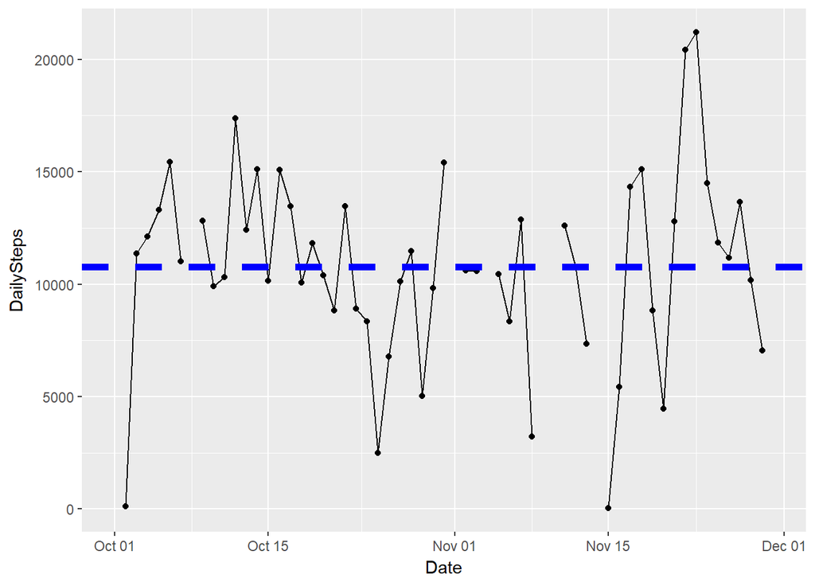

```r
library(ggplot2)
ggplot(DailyData,aes(Date,DailySteps))+geom_point(na.rm=TRUE)+geom_line(na.rm=TRUE)+geom_hline(aes(yintercept=DailyMeanSteps),color='blue',size=2,linetype=2)
```

overall average ofsteps is shown as dashed blue line. Daily data is plotted for each day.

## Part 5: The 5-minute interval that, on average, contains the maximum number of steps

Need to look at the original 5 minute data and find the maximum value.

```r
MaxSteps<-subset(ActivityData,steps==max(ActivityData$steps,na.rm=TRUE))
```

806 steps was maximum observed in a 5 minute interval and that occourred on 2012-11-27 interval number 615

## Part 6: Code to describe and show a strategy for imputing missing data

Replace missing data with the average (mean) into Activity Data then reproduce DailyData data.frame

```r
ActivityData$steps[is.na(ActivityData$steps)]<-DailyMeanSteps/288

DailyData<-aggregate(ActivityData$steps, list(ActivityData$date),FUN=sum)
names(DailyData)[1]<-"Date"
names(DailyData)[2]<-"DailySteps"
DailyData$Date<-as.Date(DailyData$Date, format="%Y-%m-%d")

summary(ActivityData)
```

```
##      steps                date          interval
##  Min.   :  0.00   2012-10-01:  288   Min.   :   0.0
##  1st Qu.:  0.00   2012-10-02:  288   1st Qu.: 588.8
##  Median :  0.00   2012-10-03:  288   Median :1177.5
##  Mean   : 37.38   2012-10-04:  288   Mean   :1177.5
##  3rd Qu.: 37.38   2012-10-05:  288   3rd Qu.:1766.2
##  Max.   :806.00   2012-10-06:  288   Max.   :2355.0
##                   (Other)   :15840
```

## Part 7: Histogram of the total number of steps taken each day after missing values are imputed

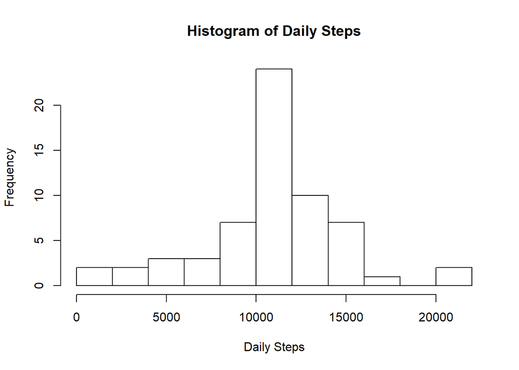

```r
hist(DailyData$DailySteps,breaks=10,xlab="Daily Steps",main="Histogram of Daily Steps")
```

## Part 8: Panel plot comparing the average number of steps taken per 5-minute interval across weekdays and weekends

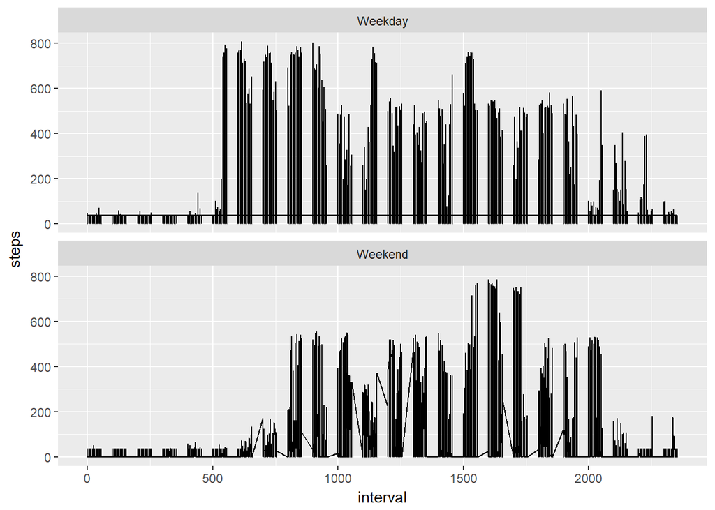

```r
library(timeDate)
ActivityData$Weekend<-isWeekend(ActivityData$date)
ActivityData$Weekend<-as.factor(ActivityData$Weekend)
levels(ActivityData$Weekend)<-c("Weekday","Weekend")
ggplot(data=ActivityData, aes(x=interval,y=steps,group=Weekend))+geom_line()+facet_wrap(~Weekend,ncol=1)
```

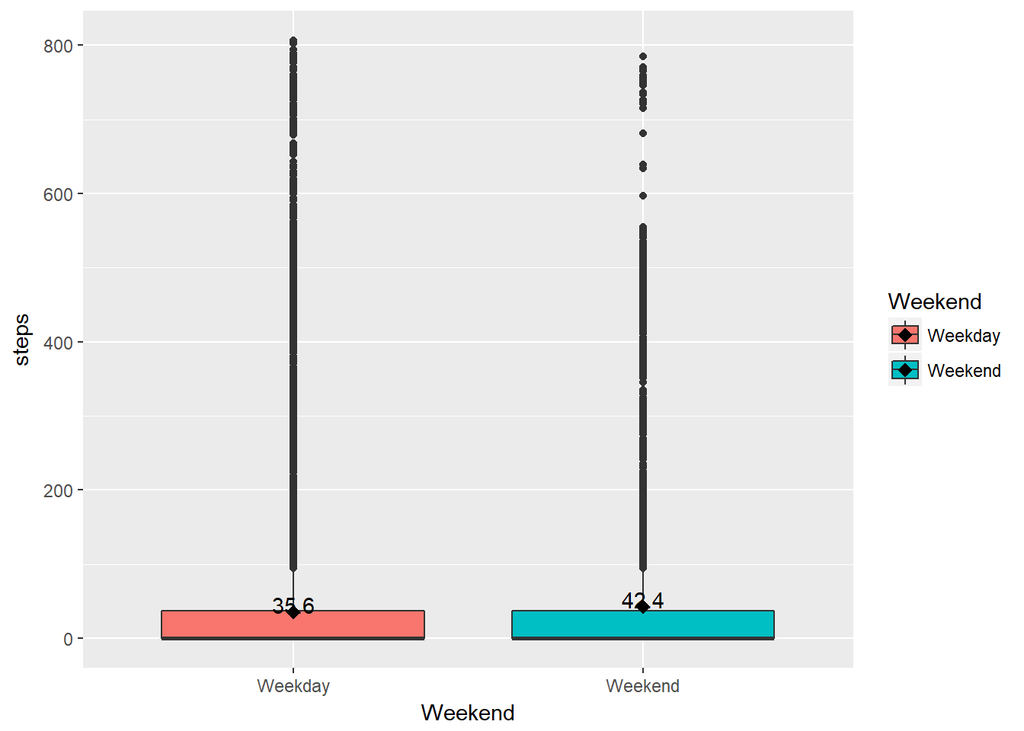

```r
means<-aggregate(steps~Weekend,ActivityData,mean)
means$steps<-round(means$steps,1)
ggplot(data=ActivityData, aes(x=Weekend,y=steps,fill=Weekend))+geom_boxplot()+stat_summary(fun.y=mean,geom="point",shape=18,size=3)+geom_text(data=means,aes(label=steps,y=steps+10))
```